# Использование dplyr, ggplot2

Громов В.П.

# Задача

С помощью скачанного файла `bs.csv` выполнить варианты. Переменная `V1` - время, `V3` - координаты точек (вспомогательная переменная `V2` - порядковый номер точки).

**Первый вариант**: написать функцию, которая для заданного момента времени выводит зависимости переменных, начиная с `V4`, от `x` (`V3`)

**Второй вариант**: для заданного значения `x` (или, проще, `V2` - порядкового номера точки) вывести зависимости переменных `V4` и далее от `t` (`V1`)

## Решение (код)

Решены оба варианта. Работают схоже.  
В решении потребовались следующие библиотеки: `ggplot2`, `dplyr`, `reshape2`

Список функций:

- `solveT` - строит график для заданной переменной в заданный момент времени
- `solveAllT` - строит графики для одной и больше переменной в заданный момент времени
- `solveX` - строит график для заданной переменной в заданной точке
- `solveAllX` - строит графк для заданных переменных в заданной точке
- `checkNames` - проверяет, есть ли указанные именя колонок в датафрейме
- `findMax` - находит максимальное в каждой из колонок
- `divide` - нормализирует колонки (значения по модулю меньше 1)
- `readData` - чтение информации из файла
- `renameV` - переименование первых трех колонок (для удобства)

## Вспомогательные функции

### Чтение файла

```r
readData = function(source){
  data <- read.csv(source)
  return(data)
}
```

Читает файл по заданному пути. Файл должен быть с расширением `.csv`. Отдает датафрейм, созданный из этого файла.

### Переименование колонок

```r
renameV = function(data){
  colnames(data)[1] <- "t"
  colnames(data)[2] <- "n"
  colnames(data)[3] <- "x"
  return(data)
}
```

Переименовывает первые три колонки согласно условию задания. Возвращает датафрейм.

### Проверка на наличие нужных колонок

```r
checkNames = function(data, names){
  Vs = names(data)
  for(i in 1: length(names)){
    if(!names[i] %in% Vs) return(FALSE)
  }
  return(TRUE)
}
```

Проверяет, есть ли в данном датафрейме **ВСЕ** колонки из списка названий. Если хотя бы одной нет, возвращает `FALSE`. Если есть все, то – `TRUE`

### Нахождение максимального

```r
findMax = function(data, names){
  res = c()
  for(i in 1: length(names)){
    if(abs(max(data[[names[i]]])) > abs(min(data[[names[i]]])))
      res = c(res, abs(max(data[[names[i]]])))
    else
      res = c(res, abs(min(data[[names[i]]])))
  }
  return(res)
}
```

Находит максимальное значение в каждой колонке датафрейма, указанной в списке имен. Возвращает список максимальных значений в том порядке, в котором были введены названия.

### Деление

```r
divide = function(data, names){
  maxes = findMax(data, names)
  for(i in 1: length(names)){
    if(maxes[i] > 1)
      data[[names[i]]] = data[[names[i]]] / maxes[i]
  }
  return(data)
}
```

## Основные функции

### Построение графика переменной для заданного момента времени

```r
solveT = function(data, time = 0, Vn = "V4"){

  if(!checkNames(data, c(Vn))){
    print("Wrong column name")
    return()
  }

  nData = data %>% select(t, x, Vn) %>%
    filter(t == time)

  ttitle = paste(Vn,",   Time =", time)
  gplot = ggplot(nData, aes(x = x, y = nData[[Vn]])) + geom_point(color = "orange") +
    theme_bw() + labs(y = "y", title = ttitle)

  return(gplot)
}
```

Возвращает график зависимости `Vn` (где n = 4, 8, 9, 10, 11, 12) от `x` (V3) в заданный момент времени `t` (`time`). Если указана колонка, которой нет в датафрейме, то выведет сообщение `"Wrong column name"` и завершит работу. Функция не отображает график, а только его строит. Возвращает `ggplot`

### Построение графика нескольких переменных для заданного момента времени

```r
solveAllT = function(data, time = 0, Vs = c()){

  if(length(Vs) == 0){
    print("There is no data to display")
    return()
  }
  if(!checkNames(data, Vs)){
    print("There is no data for one (or more) of colnames given")
    return()
  }

  nData = data %>% filter(t == time) %>%
    select("t", "n", "x", Vs)
  nData = divide(nData, Vs)
  nData <- melt(nData, id.vars = c("t", "n", "x"))

  gplot <- ggplot(nData, aes(x, value, color = variable)) + labs(y = "y", color = "V", title = paste("Time =", time)) +
    geom_line(size = 2) +
    theme_bw() + ylim(-1.1, 1.1)

  return(gplot)
}
```

### Построение графика переменной для заданной точки

```r
solveX = function(data, X = 0, Vn = "V4"){

  if(!checkNames(data, c(Vn))){
    print("Wrong column name")
    return()
  }

  nData = data %>% select(t, x, Vn) %>%
    filter(x == X)

  ttitle = paste(Vn,",   X =", X)
  gplot = ggplot(nData, aes(x = t, y = nData[[Vn]])) + geom_point(color = "orange") +
    theme_bw() + labs(y = "y", title = ttitle)

  return(gplot)
}
```

Работает аналогично `solveT`, только вместо заданного времени у функции задана точка `x`. На выход дается `ggplot`.

### Построение графика нескольких переменных для заданной точки

```r
solveAllX = function(data, X = 0, Vs = c()){

  if(length(Vs) == 0){
    print("There is no data to display")
    return()
  }
  if(!checkNames(data, Vs)){
    print("There is no data for one (or more) of colnames given")
    return()
  }

  nData = data %>% filter(x == X) %>%
    select("t", "n", "x", Vs)
  nData = divide(nData, Vs)
  nData <- melt(nData, id.vars = c("t", "n", "x"))

  gplot <- ggplot(nData, aes(t, value, color = variable)) + labs(y = "y", color = "V", title = paste("X=", X)) +
    geom_line(size = 2) +
    theme_bw() + ylim(-1.1, 1.1)

  return(gplot)
}
```

## Решение (Итоговый код)

```r
library(ggplot2)
library(dplyr)
library(reshape2)
options(warn=-1)

# Variant 1

## Finds dependence Vn on x for a given time from data.frame "data"; returns ggplot (doesn't print it)
solveT = function(data, time = 0, Vn = "V4"){

  if(!checkNames(data, c(Vn))){
    print("Wrong column name")
    return()
  }

  nData = data %>% select(t, x, Vn) %>%
    filter(t == time)

  ttitle = paste(Vn,",   Time =", time)
  gplot = ggplot(nData, aes(x = x, y = nData[[Vn]])) + geom_point(color = "orange") +
    theme_bw() + labs(y = "y", title = ttitle)

  return(gplot)
}
## Returns all dependences Vn on x from data.frame "data"; returns ggplot (doesn't print it)
solveAllT = function(data, time = 0, Vs = c()){

  if(length(Vs) == 0){
    print("There is no data to display")
    return()
  }
  if(!checkNames(data, Vs)){
    print("There is no data for one (or more) of colnames given")
    return()
  }

  nData = data %>% filter(t == time) %>%
    select("t", "n", "x", Vs)
  nData = divide(nData, Vs)
  nData <- melt(nData, id.vars = c("t", "n", "x"))

  gplot <- ggplot(nData, aes(x, value, color = variable)) + labs(y = "y", color = "V", title = paste("Time =", time)) +
    geom_line(size = 2) +
    theme_bw() + ylim(-1.1, 1.1)

  return(gplot)
}


# Variant 2

## Finds dependence Vn on t for a given time from data.frame "data"; returns ggplot (doesn't print it)
solveX = function(data, X = 0, Vn = "V4"){

  if(!checkNames(data, c(Vn))){
    print("Wrong column name")
    return()
  }

  nData = data %>% select(t, x, Vn) %>%
    filter(x == X)

  ttitle = paste(Vn,",   X =", X)
  gplot = ggplot(nData, aes(x = t, y = nData[[Vn]])) + geom_point(color = "orange") +
    theme_bw() + labs(y = "y", title = ttitle)

  return(gplot)
}
## Returns all dependences Vn on t from data.frame "data"; returns ggplot (doesn't print it)
solveAllX = function(data, X = 0, Vs = c()){

  if(length(Vs) == 0){
    print("There is no data to display")
    return()
  }
  if(!checkNames(data, Vs)){
    print("There is no data for one (or more) of colnames given")
    return()
  }

  nData = data %>% filter(x == X) %>%
    select("t", "n", "x", Vs)
  nData = divide(nData, Vs)
  nData <- melt(nData, id.vars = c("t", "n", "x"))

  gplot <- ggplot(nData, aes(t, value, color = variable)) + labs(y = "y", color = "V", title = paste("X=", X)) +
    geom_line(size = 2) +
    theme_bw() + ylim(-1.1, 1.1)

  return(gplot)
}


#Auxiliary Necessary in both variants

## Checks if is there a column with specified name
checkNames = function(data, names){
  Vs = names(data)
  for(i in 1: length(names)){
    if(!names[i] %in% Vs) return(FALSE)
  }
  return(TRUE)
}
## Finds maximum by absolute value in each column given
findMax = function(data, names){
  res = c()
  for(i in 1: length(names)){
    if(abs(max(data[[names[i]]])) > abs(min(data[[names[i]]])))
      res = c(res, abs(max(data[[names[i]]])))
    else
      res = c(res, abs(min(data[[names[i]]])))
  }
  return(res)
}
## Additional. Normalizes all of given columns (makes |values| < 1)
divide = function(data, names){
  maxes = findMax(data, names)
  for(i in 1: length(names)){
    if(maxes[i] > 1)
      data[[names[i]]] = data[[names[i]]] / maxes[i]
  }
  return(data)
}
## Reads data from source (.csv file); needs path to file (string type)
readData = function(source){
  data <- read.csv(source)
  return(data)
}
## Renames columns
renameV = function(data){
  colnames(data)[1] <- "t"
  colnames(data)[2] <- "n"
  colnames(data)[3] <- "x"
  return(data)
}
```

## Некоторые графики:

##### Работа solveT: time = 12, Vn = V10

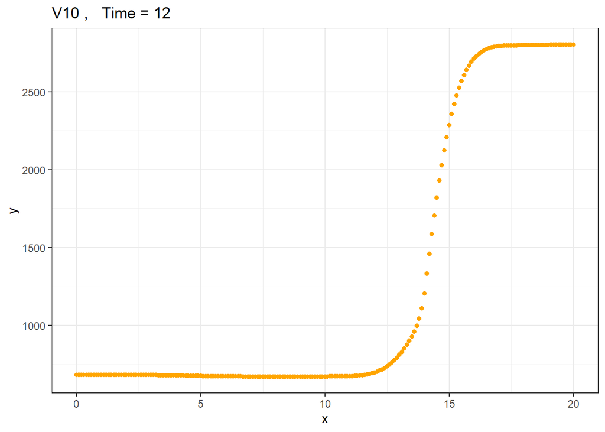

##### Работа solveAllT: time = 2, Vs = c(“V4”, “V8”, “V9”, “V10”, “V11”, “V12”)

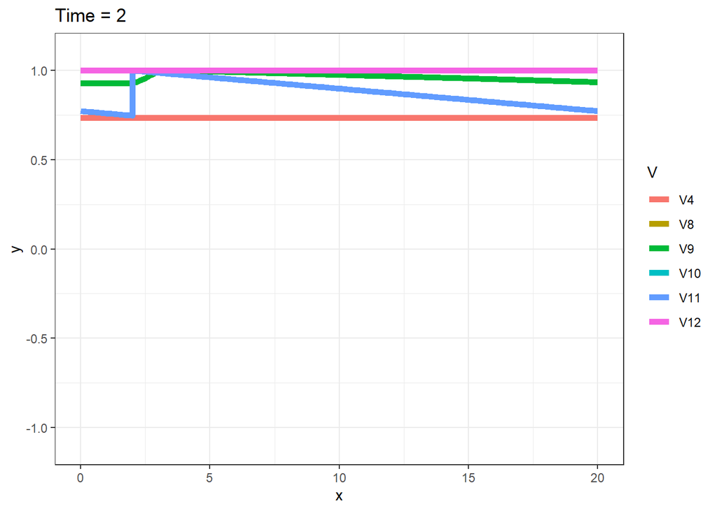

##### Работа solveX: (X = 8, Vn = V4)

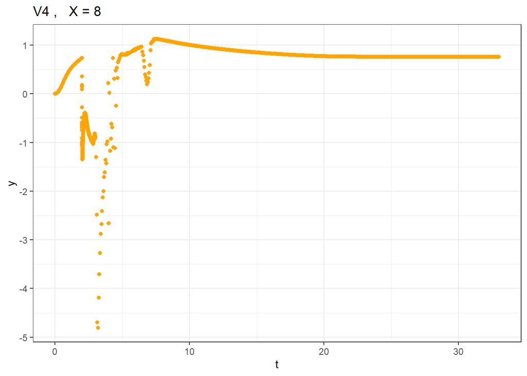

##### Работа solveAllX: X = 17, Vs = c(“V4”, “V8”, “V9”, “V11”, “V12”)

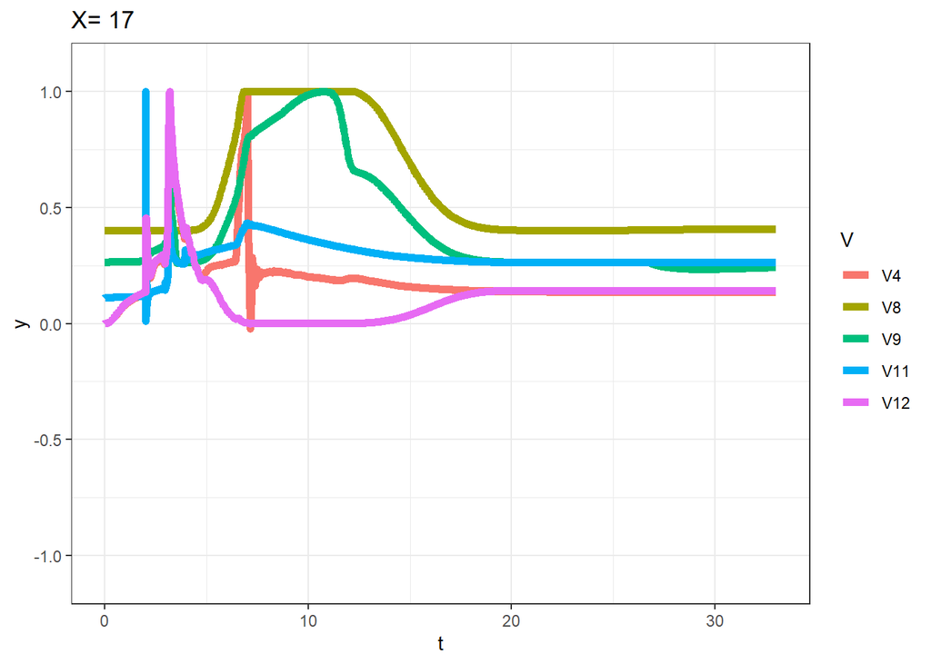